# EDA

Alex Solarski

April 19, 2017

```r
library(tidyverse)
library(lazyeval)
library(dplyr)

file_name <- 'Batting.csv'

batting_data <- read_csv(file_name)
batting_data <- batting_data %>% mutate(batting_avg = `H`/`AB`)
batting_data <- batting_data %>% mutate(`1B` = `H` - `2B` - `3B` - `HR`,
                        slugging_avg = (`1B` + `2B`*2 + `3B`*3 + `HR`*4)/`AB`,
                        base_avg = (`1B` + `2B`*2 + `3B`*3 + `HR`*4))
```

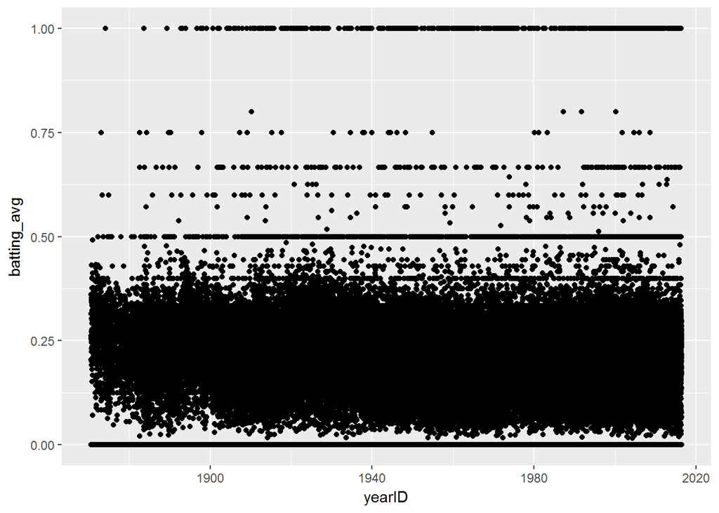

```r
ggplot(data = batting_data) +
  geom_jitter(mapping = aes(x=yearID, y=batting_avg))
```

It appears there isn’t really a trend between year and batting average as the values are all over the place.

```r
group <- "yearID"
col <- "HR"
sum_data <- batting_data %>% group_by(yearID) %>% summarise(avg_hr = mean(HR, na.rm=TRUE), max_hr = max(HR, na.rm=TRUE))

lin_reg <- lm(avg_hr ~ yearID, sum_data)
summary(lin_reg)
```

```
##
## Call:
## lm(formula = avg_hr ~ yearID, data = sum_data)
##
## Residuals:
##      Min       1Q   Median       3Q      Max
## -1.39217 -0.39985  0.01238  0.43506  1.15300
##
## Coefficients:
##               Estimate Std. Error t value Pr(>|t|)
## (Intercept) -47.095172   2.179510  -21.61   <2e-16 ***
## yearID        0.025429   0.001121   22.68   <2e-16 ***
## ---
## Signif. codes:  0 '***' 0.001 '**' 0.01 '*' 0.05 '.' 0.1 ' ' 1
##
## Residual standard error: 0.571 on 144 degrees of freedom
## Multiple R-squared:  0.7813, Adjusted R-squared:  0.7798
## F-statistic: 514.4 on 1 and 144 DF,  p-value: < 2.2e-16
```

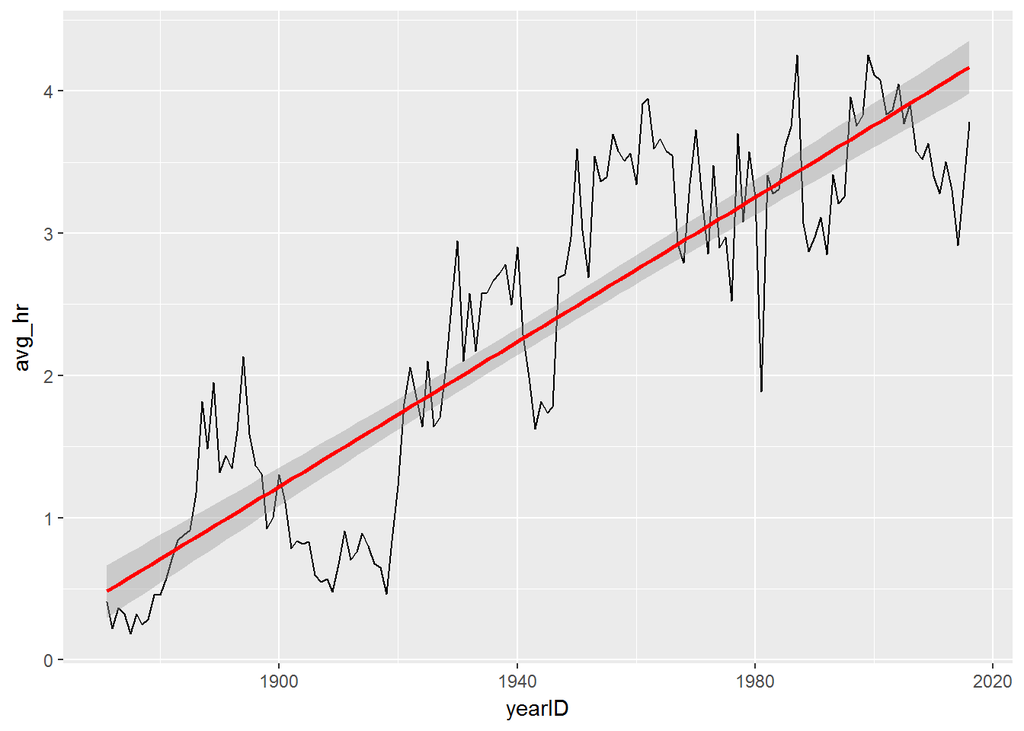

```r
ggplot(data = sum_data) +
  geom_line(mapping = aes(x=yearID, y=avg_hr)) +
  stat_smooth(method = "lm", col = "red", mapping = aes(x=yearID, y=avg_hr))
```

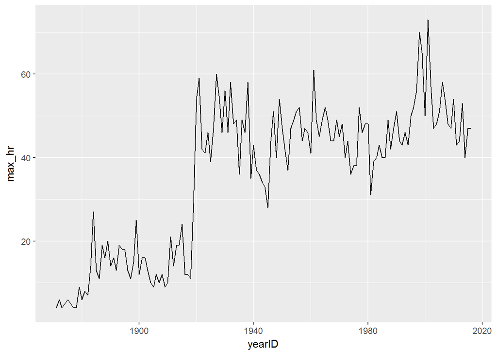

```r
ggplot(data = sum_data) +
  geom_line(mapping = aes(x=yearID, y=max_hr))
```

There is also a very big dip in 1980

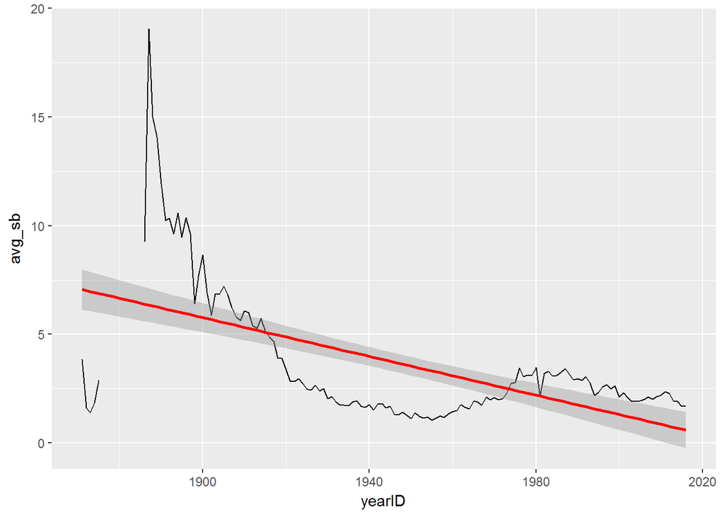

```r
sum_data <- batting_data %>% group_by(yearID) %>% summarise(avg_sb = mean(SB))


ggplot(data = sum_data) +
  geom_line(mapping = aes(x=yearID, y=avg_sb)) +
  stat_smooth(method = "lm", col = "red", mapping = aes(x=yearID, y=avg_sb))
```

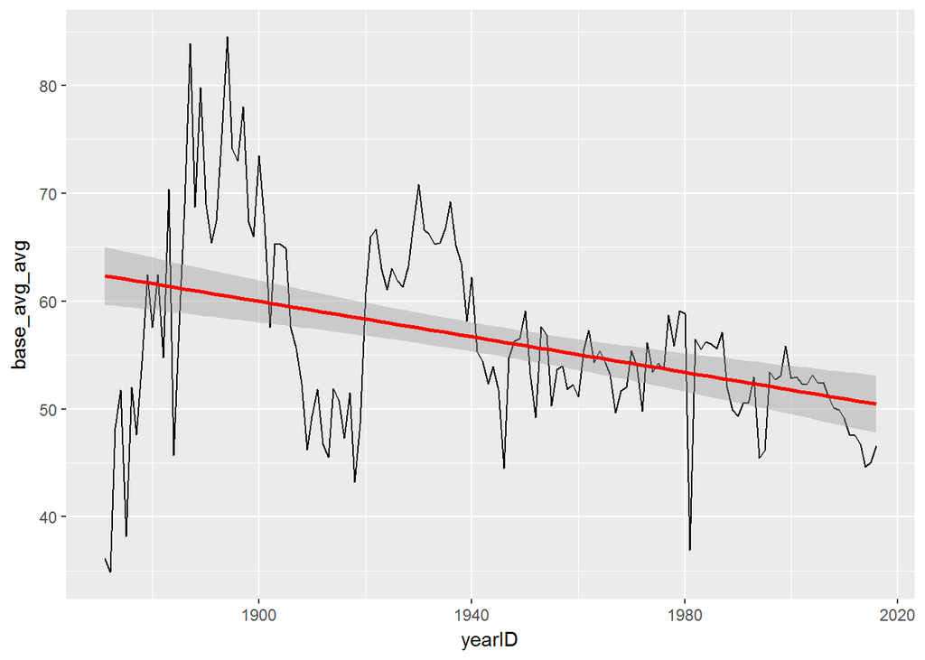

```r
sum_data <- batting_data %>% group_by(yearID) %>% summarise(base_avg_avg = mean(base_avg, na.rm=TRUE),
                                                    slug_avg_avg = mean(slugging_avg, na.rm=TRUE))

ggplot(data = sum_data) +
  geom_line(mapping = aes(x=yearID, y=base_avg_avg)) +
  stat_smooth(method = "lm", col = "red", mapping = aes(x=yearID, y=base_avg_avg))
```

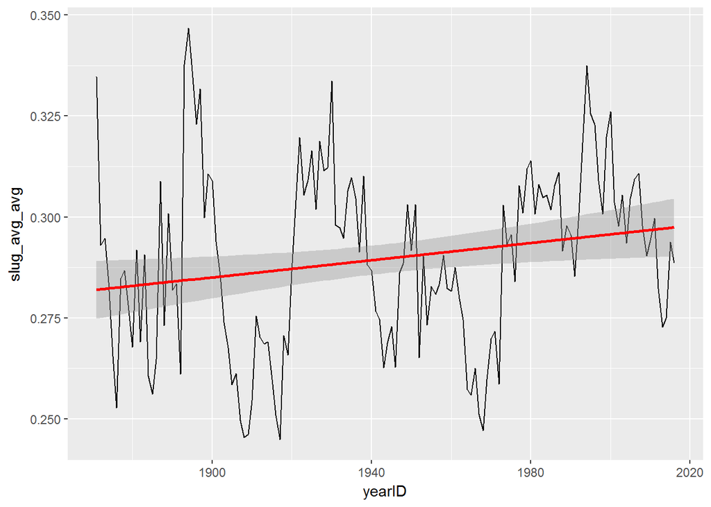

```r
ggplot(data = sum_data) +
  geom_line(mapping = aes(x=yearID, y=slug_avg_avg)) +
  stat_smooth(method = "lm", col = "red", mapping = aes(x=yearID, y=slug_avg_avg))
```

```r
file_name <- 'Salaries.csv'

sal_data <- read_csv(file_name)
```

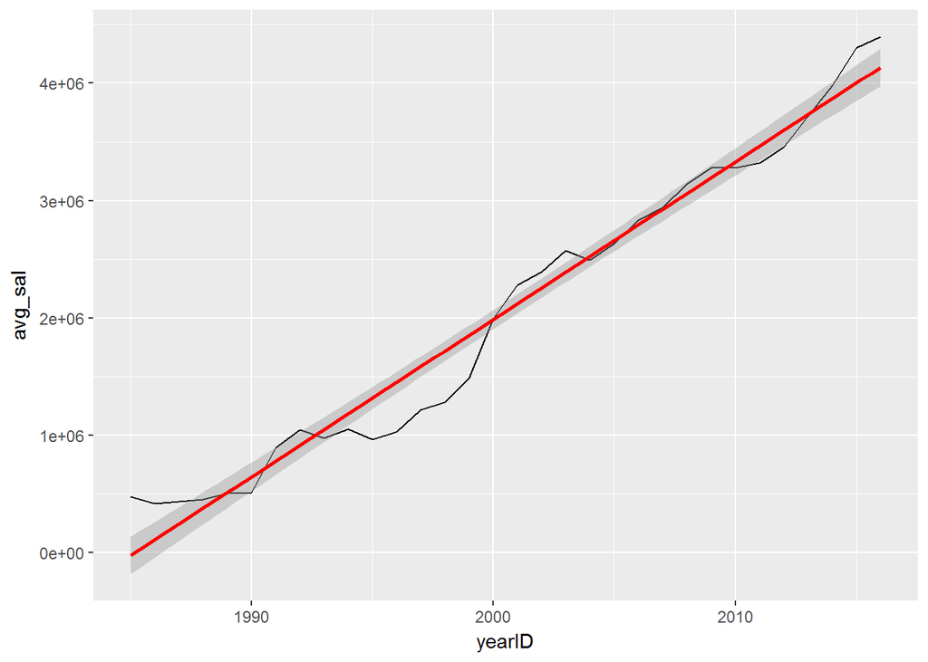

```r
sum_data <- sal_data %>% group_by(yearID) %>% summarise(avg_sal = mean(salary), max_sal = max(salary))

ggplot(data = sum_data) +
  geom_line(mapping = aes(x=yearID, y=avg_sal)) +
  stat_smooth(method = "lm", col = "red", mapping = aes(x=yearID, y=avg_sal))
```

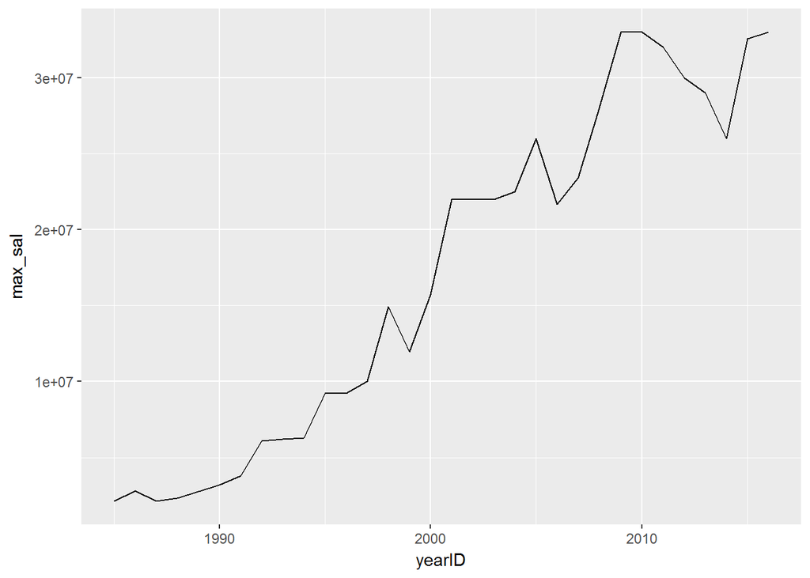

```r
ggplot(data = sum_data) +
  geom_line(mapping = aes(x=yearID, y=max_sal))
```

```r
bat_sal_data <- inner_join(batting_data, sal_data, copy=TRUE)
```

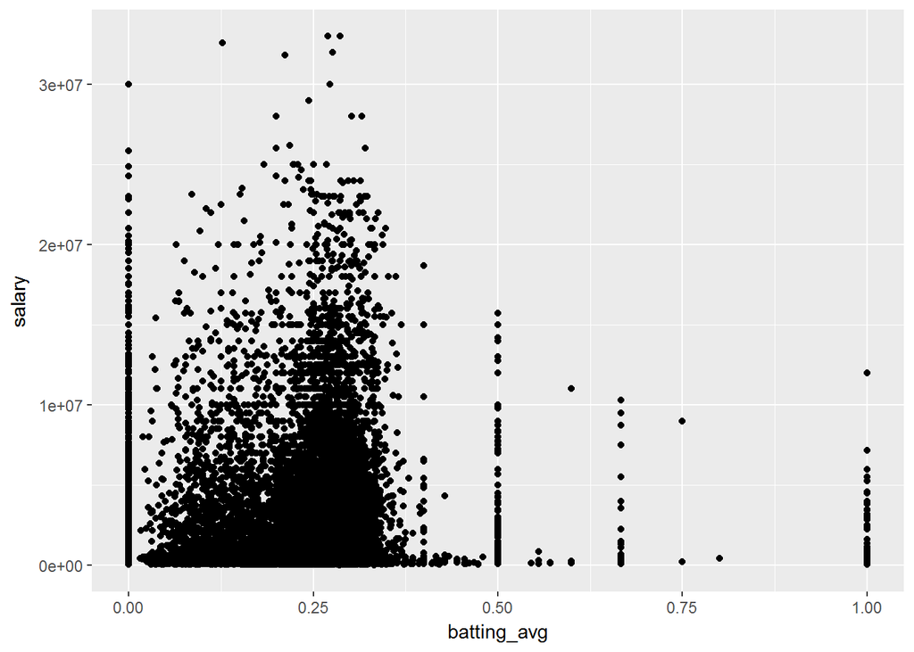

```r
ggplot(data = bat_sal_data) +
  geom_jitter(aes(x=batting_avg, y=salary))
```

As we assumed, it is very difficult to predict salary based on just one data point. Because of the multitude of positions in baseball and ways to perform without being awesome when at bat, one can command a high salary without batting well.

Because of the vast amount of data and the number of confounding variables, we have decided to build a shiny app which will allow users to explore the data. We plan to build an app that will:

-DONE - Allow users to select up to two tables to select data from -DONE - Allow users to select a date range to view results from -DONE - Allow users to select an X and Y variable to plot -DONE - Allow users to toggle between data points and an average or median line -DONE - Allow users to have a linear regression on the plot w/ results -Allow users to animate a plot over time -Allow users to pick a league to analyze, or analyze each side by side -Pick a team to analyze -Get information about a specific team/player on the plot